# Data 622 Homework #2

Trishita Nath

4/3/2022

# Homework #2

Based on the latest topics presented, bring a loan_data of your choice and create a Decision Tree where you can solve a classification or regression problem and predict the outcome of a particular feature or detail of the data used.

Switch variables to generate 2 decision trees and compare the results. Create a random forest for regression and analyze the results.

Based on real cases where desicion trees went wrong, and ‘the bad & ugly’ aspects of decision trees (https://decizone.com/blog/the-good-the-bad-the-ugly-of-using-decision-trees), how can you change this perception when using the decision tree you created to solve a real problem?

Format: document with screen captures & analysis.

## Data Exploration

I will the loan_data on loan approval status that I uploaded on GitHub.

### Loading Data

```
## [1] 614  13
```

| Loan_ID | Gender | Married | Dependents | Education | Self_Employed | ApplicantIncome | CoapplicantIncome | LoanAmount | Loan_Amount_Term | Credit_History | Property_Area | Loan_Status |
| --- | --- | --- | --- | --- | --- | --- | --- | --- | --- | --- | --- | --- |
| LP001002 | Male | No | 0 | Graduate | No | 5849 | 0 | NA | 360 | 1 | Urban | Y |
| LP001003 | Male | Yes | 1 | Graduate | No | 4583 | 1508 | 128 | 360 | 1 | Rural | N |
| LP001005 | Male | Yes | 0 | Graduate | Yes | 3000 | 0 | 66 | 360 | 1 | Urban | Y |
| LP001006 | Male | Yes | 0 | Not Graduate | No | 2583 | 2358 | 120 | 360 | 1 | Urban | Y |
| LP001008 | Male | No | 0 | Graduate | No | 6000 | 0 | 141 | 360 | 1 | Urban | Y |
| LP001011 | Male | Yes | 2 | Graduate | Yes | 5417 | 4196 | 267 | 360 | 1 | Urban | Y |

For this loan_data, the target variable for my analysis is the `Loan_Status`

## Data Processing

### Missing Values

Below is te summary of the missing values per feature

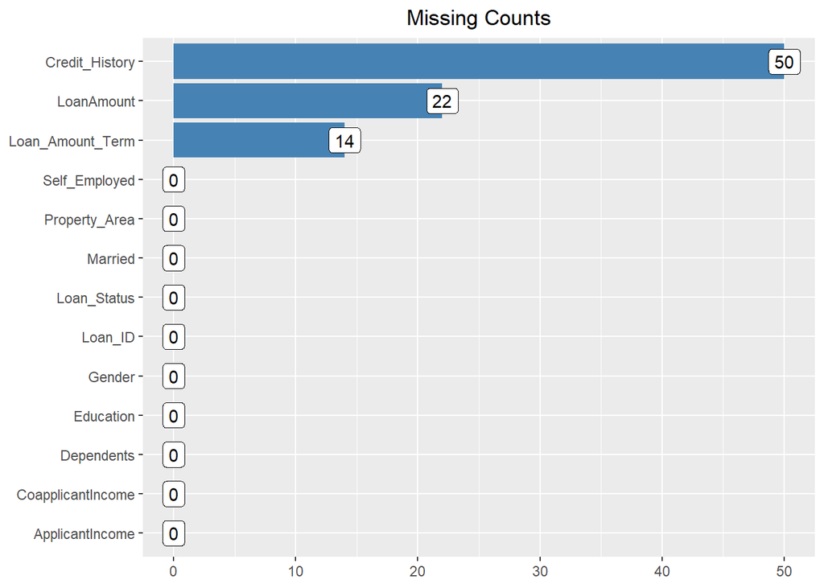

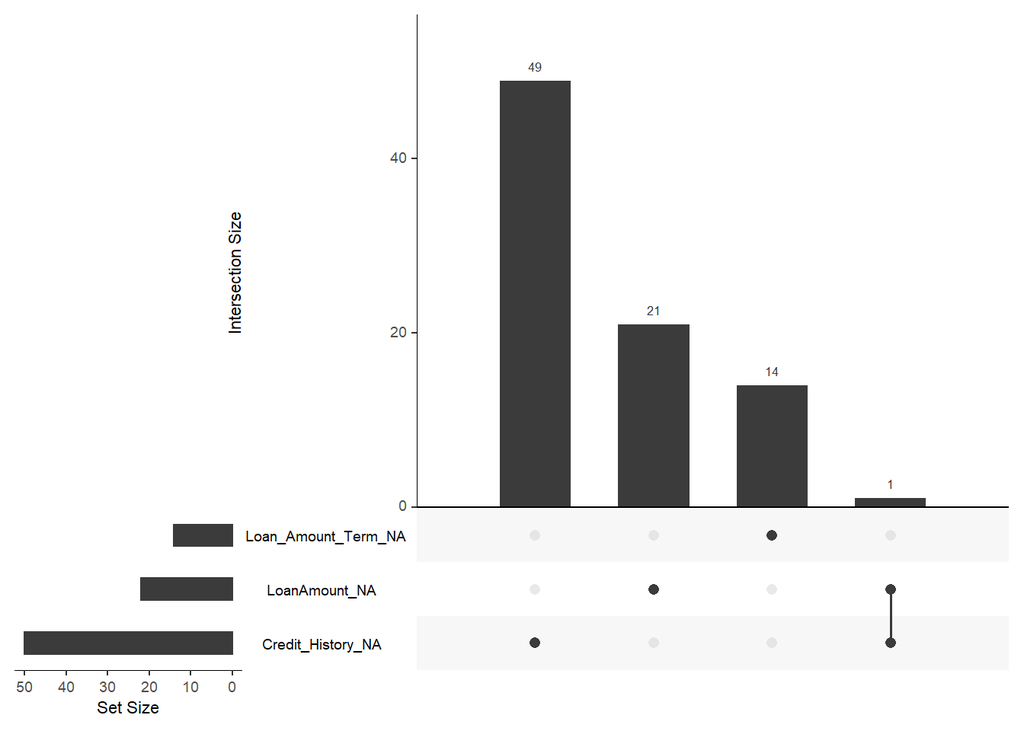

### Imputing Data

I will remove the `Loan_ID` variable, convert categorical variables into factors then impute the loan_data using the mice package following Random Forest method.

|  | Gender | Married | Dependents | Education | Self_Employed | ApplicantIncome | CoapplicantIncome | LoanAmount | Loan_Amount_Term | Credit_History | Property_Area | Loan_Status |
| --- | --- | --- | --- | --- | --- | --- | --- | --- | --- | --- | --- | --- |
|  | : 13 | : 3 | : 15 | Graduate :480 | : 32 | Min. : 150 | Min. : 0 | Min. : 9.0 | Min. : 12 | 0: 92 | Rural :179 | N:192 |
|  | Female:112 | No :213 | 0 :345 | Not Graduate:134 | No :500 | 1st Qu.: 2878 | 1st Qu.: 0 | 1st Qu.:100.0 | 1st Qu.:360 | 1:522 | Semiurban:233 | Y:422 |
|  | Male :489 | Yes:398 | 1 :102 | NA | Yes: 82 | Median : 3812 | Median : 1188 | Median :128.0 | Median :360 | NA | Urban :202 | NA |
|  | NA | NA | 2 :101 | NA | NA | Mean : 5403 | Mean : 1621 | Mean :146.1 | Mean :342 | NA | NA | NA |
|  | NA | NA | 3+: 51 | NA | NA | 3rd Qu.: 5795 | 3rd Qu.: 2297 | 3rd Qu.:167.8 | 3rd Qu.:360 | NA | NA | NA |
|  | NA | NA | NA | NA | NA | Max. :81000 | Max. :41667 | Max. :700.0 | Max. :480 | NA | NA | NA |

## Model Building

### Decision Tree

#### Data Splitting

I will split the data into training and testing datasets in the ratio 80:20

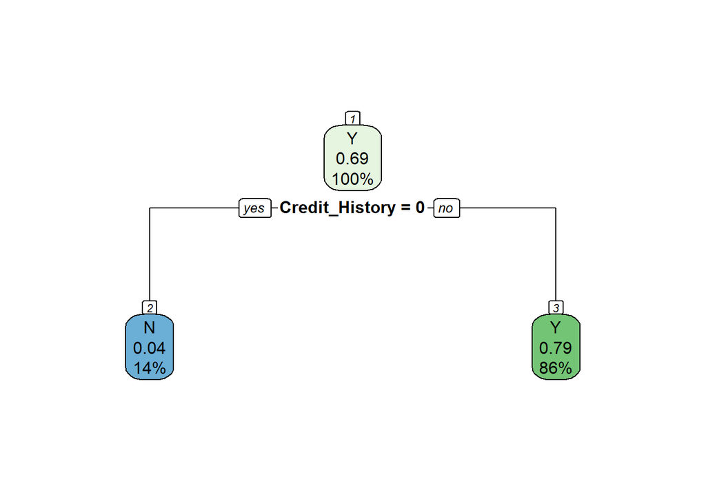

```
## Call:
## rpart(formula = Loan_Status ~ ., data = train_factored, method = "class")
##   n= 492
##
##          CP nsplit rel error    xerror       xstd
## 1 0.4090909      0 1.0000000 1.0000000 0.06679061
## 2 0.0100000      1 0.5909091 0.5909091 0.05592289
##
## Variable importance
## Credit_History
##            100
##
## Node number 1: 492 observations,    complexity param=0.4090909
##   predicted class=Y  expected loss=0.3130081  P(node) =1
##     class counts:   154   338
##    probabilities: 0.313 0.687
##   left son=2 (69 obs) right son=3 (423 obs)
##   Primary splits:
##       Credit_History   splits as  LR,       improve=66.469020, (0 missing)
##       Property_Area    splits as  LRL,      improve= 3.966673, (0 missing)
##       Education        splits as  RL,       improve= 2.301810, (0 missing)
##       ApplicantIncome  < 1903 to the left,  improve= 2.256965, (0 missing)
##       Loan_Amount_Term < 420  to the right, improve= 1.797663, (0 missing)
##
## Node number 2: 69 observations
##   predicted class=N  expected loss=0.04347826  P(node) =0.1402439
##     class counts:    66     3
##    probabilities: 0.957 0.043
##
## Node number 3: 423 observations
##   predicted class=Y  expected loss=0.2080378  P(node) =0.8597561
##     class counts:    88   335
##    probabilities: 0.208 0.792
```

Credit history seems to be an important predictor for loan approval.

```
##             N          Y
## 1   0.2080378 0.79196217
## 8   0.9565217 0.04347826
## 9   0.2080378 0.79196217
## 10  0.2080378 0.79196217
## 21  0.9565217 0.04347826
## 34  0.2080378 0.79196217
## 39  0.2080378 0.79196217
## 41  0.2080378 0.79196217
## 42  0.2080378 0.79196217
## 45  0.2080378 0.79196217
## 47  0.2080378 0.79196217
## 48  0.2080378 0.79196217
## 50  0.2080378 0.79196217
## 52  0.2080378 0.79196217
```

[output cut: 108 more lines]

```
## Confusion Matrix and Statistics
##
##           Reference
## Prediction   N   Y
##          N  66   3
##          Y  88 335
##
##                Accuracy : 0.815
##                  95% CI : (0.7779, 0.8484)
##     No Information Rate : 0.687
##     P-Value [Acc > NIR] : 9.652e-11
##
##                   Kappa : 0.4939
##
##  Mcnemar's Test P-Value : < 2.2e-16
##
##             Sensitivity : 0.4286
##             Specificity : 0.9911
##          Pos Pred Value : 0.9565
##          Neg Pred Value : 0.7920
##              Prevalence : 0.3130
##          Detection Rate : 0.1341
##    Detection Prevalence : 0.1402
##       Balanced Accuracy : 0.7098
##
##        'Positive' Class : N
##
```

The model is 81.5% accurate.

#### Regression Model

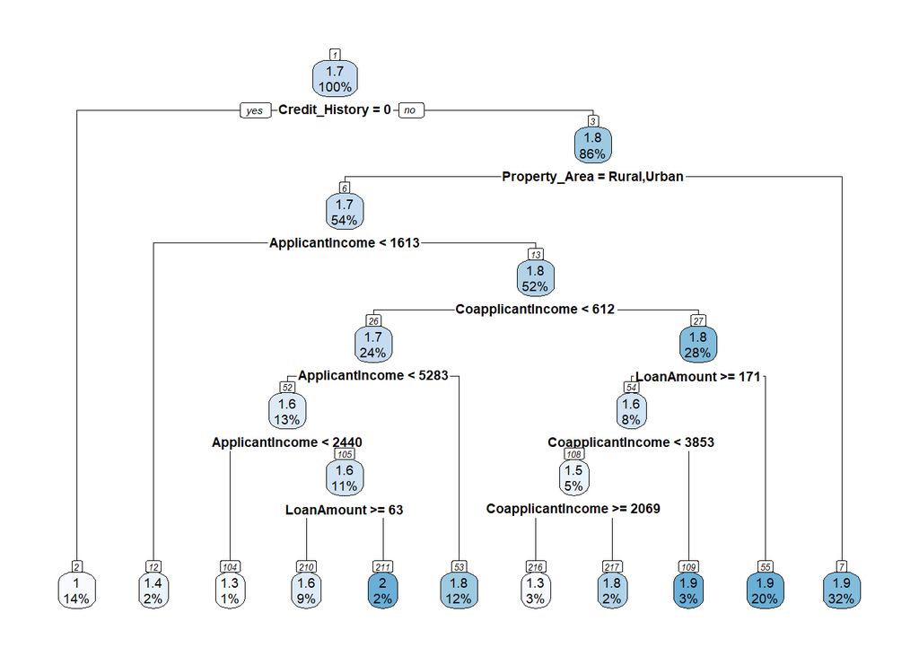

### Random Forest

Random Forest reduces overfitting problem in decision trees and also reduces the variance and therefore improves the accuracy.

```
##
## Call:
##  randomForest(formula = Loan_Status ~ ., data = train_factored,      method = "class")
##                Type of random forest: classification
##                      Number of trees: 500
## No. of variables tried at each split: 3
##
##         OOB estimate of  error rate: 19.51%
## Confusion matrix:
##    N   Y class.error
## N 70  84  0.54545455
## Y 12 326  0.03550296
```

```
##   1   8   9  10  21  34  39  41  42  45  47  48  50  52  54  57  59  70  74  77
##   Y   N   Y   Y   N   Y   Y   Y   Y   Y   Y   Y   Y   Y   Y   Y   Y   N   N   Y
##  80  86  88  98 114 118 123 136 139 144 146 148 149 155 158 161 163 182 195 198
##   Y   Y   Y   Y   Y   Y   N   Y   N   Y   Y   Y   Y   Y   Y   Y   N   Y   Y   Y
## 200 202 216 220 226 233 242 247 249 255 256 261 268 270 273 275 280 281 292 299
##   Y   N   Y   Y   Y   Y   Y   Y   Y   N   N   Y   N   Y   Y   Y   Y   N   N   Y
## 311 312 317 325 327 328 332 336 344 347 348 351 352 355 356 367 371 374 375 376
##   Y   Y   Y   Y   N   Y   Y   Y   Y   N   Y   Y   Y   Y   Y   Y   Y   N   Y   Y
## 385 390 396 397 399 401 404 412 419 422 434 436 460 463 468 487 490 495 496 500
##   Y   Y   Y   N   Y   N   Y   Y   Y   N   Y   Y   Y   Y   Y   N   Y   N   Y   N
## 503 530 532 536 544 546 547 549 556 559 561 562 566 572 575 579 580 582 593 599
##   Y   Y   Y   Y   Y   Y   Y   N   Y   Y   Y   Y   N   N   Y   Y   Y   Y   Y   Y
## 603 610
##   Y   Y
## Levels: N Y
```

## Conclusion

In my opinion, decision tree offers better performance when analyzing a feature of a loan_data. Random Forest is good to avoid low quality of data but might build a tree that will not take into consideration the significance that the“Feature” has in the final decision.